# RNA-seq数据差异基因分析

分子细胞科学卓越创新中心生物信息平台

5 June 2020

#### Abstract

本文描述了bulk RNA-seq分析流程中差异分析子模块，该模块可以得到差异表达基因，是后续功能富集等分析的基础。该模块用R语言编写。

# 1 分析流程示意图

该模块需要输入两方面的信息，利用基因水平的表达量和分组信息来完成差异基因的分析。表达量可用来自于DataSummary模块生成的*_raw.RData文件，分组信息需要自行提供，如下图所示。

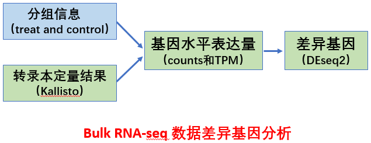

# 2 输出

## 2.1 火山图

火山图可以展示分组中所有上下调基因的总体分布情况，横坐标表示基因在不同样本中的表达倍数变化( Log2 fold-change )，纵坐标表示表达差异的显著性水平( -log10(FDR) )。红色点表示上调基因，蓝色表示下调基因，如下图所示。

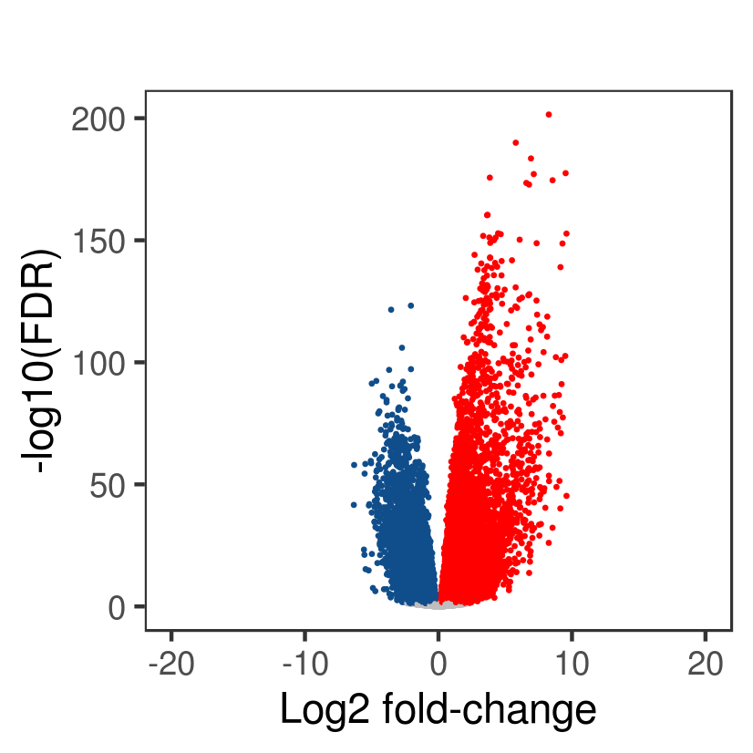

## 2.2 差异基因表格

差异基因表达分析的输入数据为基因表达水平的reads数，本次分析使用的软件是DESeq2<sup>1</sup>，设置的阈值为|log2FC| > 0；FDR < 0.05，差异结果的文件内容如下所示：

| gene | treatment_Log2TPM | control_Log2TPM | log2FoldChange | pvalue | padj | DGE |
| --- | --- | --- | --- | --- | --- | --- |
| ENSG00000000003.15 TSPAN6 | 18.93000 | 13.870 | 0.6932322 | 0.0000000 | 0.0000000 | UP |
| ENSG00000000005.6 TNMD | 0.05491 | 1.260 | -4.2431818 | 0.0000000 | 0.0000000 | DN |
| ENSG00000000419.12 DPM1 | 70.66000 | 49.260 | 0.7827346 | 0.0000000 | 0.0000000 | UP |
| ENSG00000000457.14 SCYL3 | 7.32700 | 7.840 | 0.1198781 | 0.0827933 | 0.1182141 | NC |
| ENSG00000000460.17 C1orf112 | 9.48300 | 3.661 | 1.5936468 | 0.0000000 | 0.0000000 | UP |

注：  
gene：基因的ID，含ENSEMBL ID和SYMBOL，以空格分隔；  
treatment_Log2TPM：处理组样本中基因的log2转换后的TPM值；  
control_Log2TPM：对照组样本中基因的log2转换后的TPM值；  
log2FoldChange：筛选阈值，是实验组与对照组表达量的差异倍数取2为底的对数；  
pvalue：显著性检验的p值；  
padj：多重假设检验校正后的p值；  
DGE：调控模式，UP表示上调，DN表示下调，NC表示没有变化。

# 3 参考文献

- [1] Love M I, Huber W, Anders S. Moderated estimation of fold change and dispersion for RNA-seq data with DESeq2[J]. Genome biology, 2014, 15(12): 1-21